# Fine-Tuning Our Recession Prediction Features

Now that we've got a working model, let's optimize it! We'll experiment with different feature engineering approaches to squeeze out every bit of predictive power we can get from our economic data.

```python
# Import notebook utilities
from notebook_utils import init_notebook, load_data, display_data_info, save_figure
import os
import matplotlib.pyplot as plt

# Initialize notebook environment
init_notebook()

# Import from econ_downturn package
from econ_downturn import (
    normalize_data, apply_mda, create_discriminant_time_series,
    plot_feature_importance, plot_discriminant_time_series,

    # Advanced feature engineering functions
    engineer_features_with_custom_lags, create_interaction_terms,
    apply_sentiment_transformations, select_features
)
```

[output not shown]

## Getting Our Data Ready

Let's start by loading all our data sources and getting everything set up for our optimization experiments.

```python
# Load all data using the utility function
merged_data = load_data(use_cached=False)  # Force reload from original sources

# Display information about the dataset
display_data_info(merged_data)
```

```
Loading data from original sources...
2025-06-12 13:49:32,368 - econ_downturn.data.data_loader - INFO - Loaded FRED data with shape: (15510, 10)
2025-06-12 13:49:32,371 - econ_downturn.data.data_loader - INFO - Loaded NBER recession data with shape: (653, 1)
2025-06-12 13:49:32,374 - econ_downturn.data.data_loader - INFO - Loaded UMich data with shape: (653, 2)
2025-06-12 13:49:32,375 - econ_downturn.data.data_loader - INFO - Initialized merged dataset with 'FRED' data
2025-06-12 13:49:32,378 - econ_downturn.data.data_loader - INFO - Added 'NBER' data to merged dataset
2025-06-12 13:49:32,379 - econ_downturn.data.data_loader - INFO - Added 'UMICH' data to merged dataset
2025-06-12 13:49:32,380 - econ_downturn.data.data_loader - INFO - Merged dataset shape: (15657, 13)
2025-06-12 13:49:32,410 - econ_downturn.data.data_loader - INFO - Saved merged dataset to /home/mattgroho/github/economic-downturn-detector/data/processed/merged_data.csv
Loaded and merged data with shape: (15657, 13)
Dataset Information:
Time Range: 1970-01-01 00:00:00 to 2024-05-31 00:00:00
Number of Observations: 15657
Number of Features: 13

Summary Statistics:
```

|  | GDP | UNEMPLOYMENT | CPI | FED_FUNDS | YIELD_CURVE | INITIAL_CLAIMS | INDUSTRIAL_PROD | RETAIL_SALES | HOUSING_STARTS | CONSUMER_SENTIMENT | recession | SENTIMENT | INFLATION_EXPECTATION |
| --- | --- | --- | --- | --- | --- | --- | --- | --- | --- | --- | --- | --- | --- |
| count | 218.000000 | 653.000000 | 653.000000 | 653.000000 | 11998.000000 | 2.839000e+03 | 653.000000 | 389.000000 | 653.000000 | 589.000000 | 653.000000 | 589.000000 | 557.000000 |
| mean | 12837.776711 | 6.110260 | 158.663954 | 4.910490 | 0.868401 | 3.733381e+05 | 74.982246 | 365236.395887 | 1435.917305 | 84.583531 | 0.128637 | 84.583531 | 3.590126 |
| std | 5217.489014 | 1.709394 | 73.783619 | 3.898737 | 0.925610 | 2.450608e+05 | 22.585732 | 138186.138422 | 410.165486 | 13.111529 | 0.335054 | 13.111529 | 1.625392 |
| min | 5299.672000 | 3.400000 | 37.900000 | 0.050000 | -2.410000 | 1.890000e+05 | 36.388100 | 158647.000000 | 478.000000 | 50.000000 | 0.000000 | 50.000000 | 0.400000 |
| 25% | 7760.008000 | 4.900000 | 100.100000 | 1.510000 | 0.190000 | 3.010000e+05 | 51.806000 | 264067.000000 | 1176.000000 | 74.300000 | 0.000000 | 74.300000 | 2.800000 |
| 50% | 12216.346500 | 5.800000 | 159.800000 | 5.050000 | 0.830000 | 3.460000e+05 | 78.919700 | 349869.000000 | 1465.000000 | 88.200000 | 0.000000 | 88.200000 | 3.000000 |
| 75% | 16937.626250 | 7.200000 | 219.035000 | 6.890000 | 1.500000 | 4.020000e+05 | 97.606000 | 443117.000000 | 1698.000000 | 94.200000 | 0.000000 | 94.200000 | 3.500000 |
| max | 23223.906000 | 14.800000 | 313.140000 | 19.100000 | 2.910000 | 6.137000e+06 | 104.103800 | 691223.000000 | 2494.000000 | 112.000000 | 1.000000 | 112.000000 | 10.400000 |

```
Missing Values:
```

|  | Missing Values | Percentage |
| --- | --- | --- |
| GDP | 15439 | 98.607652 |
| RETAIL_SALES | 15268 | 97.515488 |
| INFLATION_EXPECTATION | 15100 | 96.442486 |
| CONSUMER_SENTIMENT | 15068 | 96.238104 |
| SENTIMENT | 15068 | 96.238104 |
| UNEMPLOYMENT | 15004 | 95.829342 |
| CPI | 15004 | 95.829342 |
| FED_FUNDS | 15004 | 95.829342 |
| INDUSTRIAL_PROD | 15004 | 95.829342 |
| HOUSING_STARTS | 15004 | 95.829342 |
| recession | 15004 | 95.829342 |
| INITIAL_CLAIMS | 12818 | 81.867535 |
| YIELD_CURVE | 3659 | 23.369739 |

## Experimenting with Sentiment Lag Periods

How far back should we look at consumer sentiment to predict recessions? Let's try different lag periods - from 1 month to 2 years - and see which ones give us the best signals.

```python
# Engineer features with different lag periods for consumer sentiment
data_with_custom_lags = engineer_features_with_custom_lags(
    merged_data,
    sentiment_lags=[1, 3, 6, 12, 18, 24],
    other_lags=[1, 3, 6, 12]
)

# Save the dataset with custom lags
from econ_downturn import get_data_paths
data_paths = get_data_paths()
output_dir = data_paths['processed_dir']
os.makedirs(output_dir, exist_ok=True)
custom_lags_path = os.path.join(output_dir, 'data_with_custom_sentiment_lags.csv')
data_with_custom_lags.to_csv(custom_lags_path)
print(f"Saved dataset with custom lags to {custom_lags_path}")
```

```
Applying intelligent missing value handling...
Forward-filling GDP values (quarterly data)
Handling 15004 missing values in UNEMPLOYMENT
Handling 15004 missing values in CPI
Handling 15004 missing values in FED_FUNDS
Handling 3659 missing values in YIELD_CURVE
Handling 12818 missing values in INITIAL_CLAIMS
Handling 15004 missing values in INDUSTRIAL_PROD
Handling 15268 missing values in RETAIL_SALES
Handling 15004 missing values in HOUSING_STARTS
Handling 15068 missing values in CONSUMER_SENTIMENT
Handling 15068 missing values in SENTIMENT
Handling 15100 missing values in INFLATION_EXPECTATION
Remaining missing values after intelligent handling: {'recession': 15004}
Resampled data to M frequency, new shape: (653, 13)
Created lag variables, new shape: (653, 113)
Calculated rate of change, new shape: (653, 449)
Data shape before handling missing values: (653, 449)
Rows with missing values: 72
WARNING: 15 recession period rows have missing values
Recession periods with missing data:
[Timestamp('1970-01-31 00:00:00'), Timestamp('1970-02-28 00:00:00'), Timestamp('1970-03-31 00:00:00'), Timestamp('1970-04-30 00:00:00'), Timestamp('1970-05-31 00:00:00'), Timestamp('1970-06-30 00:00:00'), Timestamp('1970-07-31 00:00:00'), Timestamp('1970-08-31 00:00:00'), Timestamp('1970-09-30 00:00…
Dropping 13 rows with >50% missing values
Forward-filling 2112 remaining missing values
Data shape after intelligent missing value handling: (640, 449)
Saved dataset with custom lags to /home/mattgroho/github/economic-downturn-detector/data/processed/data_with_custom_sentiment_lags.csv
```

## Building Interaction Features

Sometimes the magic happens when variables work together. Let's create interaction terms between consumer sentiment and economic indicators to capture how they amplify each other's effects.

```python
# Create interaction terms
data_with_interactions = create_interaction_terms(data_with_custom_lags)

# Save the dataset with interaction terms
interactions_path = os.path.join(output_dir, 'data_with_interactions.csv')
data_with_interactions.to_csv(interactions_path)
print(f"Saved dataset with interaction terms to {interactions_path}")
```

```
Created interaction terms, new shape: (640, 461)
Saved dataset with interaction terms to /home/mattgroho/github/economic-downturn-detector/data/processed/data_with_interactions.csv
```

## Transforming Sentiment Data

Raw sentiment data is good, but transformed sentiment data might be even better. Let's try different mathematical transformations to see if we can extract more predictive power.

```python
# Apply transformations to sentiment data
data_with_transformations = apply_sentiment_transformations(data_with_interactions)

# Save the dataset with transformations
transformations_path = os.path.join(output_dir, 'data_with_transformations.csv')
data_with_transformations.to_csv(transformations_path)
print(f"Saved dataset with transformations to {transformations_path}")
```

```
Applied transformations to sentiment data, new shape: (640, 472)
Saved dataset with transformations to /home/mattgroho/github/economic-downturn-detector/data/processed/data_with_transformations.csv
```

## Finding the Best Features

We've created a lot of features - maybe too many! Let's use statistical methods to identify which ones are actually the most useful for predicting recessions.

```python
# Normalize the data
data_normalized, _ = normalize_data(data_with_transformations)

# Separate features and target
X = data_normalized.drop(columns=['recession'])
y = data_normalized['recession']

# Select features using ANOVA F-value
X_selected_anova, selected_features_anova = select_features(X, y, method='anova', k=20)

# Select features using Recursive Feature Elimination
X_selected_rfe, selected_features_rfe = select_features(X, y, method='rfe', k=20)
```

```
2025-06-12 13:49:33,106 - econ_downturn.features.normalization - INFO - Normalized data using standard method, shape: (640, 472)
Selected 20 features using ANOVA F-value
Top 10 selected features:
                       Feature       Score
456  SENTIMENT_minus_FED_FUNDS  178.577574
138       HOUSING_STARTS_roc12  163.223250
114                  GDP_roc12  157.558460
282  HOUSING_STARTS_lag1_roc12  155.882377
460              SENTIMENT_log  146.255579
461             SENTIMENT_sqrt  139.954344
131       INDUSTRIAL_PROD_roc3  139.327132
464           SENTIMENT_minmax  133.183031
9           CONSUMER_SENTIMENT  133.183031
10                   SENTIMENT  133.183031

```

[output cut: 38 more lines]

## The Sentiment Showdown

Time for the ultimate test - does consumer sentiment actually make our model better? Let's run the same analysis with and without sentiment features to see the difference.

```
MDA Model WITH Sentiment Features:
2025-06-12 13:49:36,502 - econ_downturn.features.normalization - INFO - Normalized data using standard method, shape: (640, 472)
2025-06-12 13:49:36,505 - econ_downturn.models.mda - INFO - Training set shape: (448, 471), Testing set shape: (192, 471)
2025-06-12 13:49:36,536 - econ_downturn.models.mda - INFO - Accuracy: 0.9219
2025-06-12 13:49:36,537 - econ_downturn.models.mda - INFO - Confusion Matrix:
[[159  11]
 [  4  18]]
2025-06-12 13:49:36,538 - econ_downturn.models.mda - INFO - Classification Report:
              precision    recall  f1-score   support

         0.0       0.98      0.94      0.95       170
         1.0       0.62      0.82      0.71        22

    accuracy                           0.92       192
   macro avg       0.80      0.88      0.83       192
weighted avg       0.93      0.92      0.93       192

2025-06-12 13:49:36,725 - econ_downturn.models.mda - INFO - Cross-Validation Scores: [0.9609375 0.921875  0.9140625 0.9453125 0.9609375]
2025-06-12 13:49:36,726 - econ_downturn.models.mda - INFO - Mean CV Score: 0.9406
2025-06-12 13:49:36,729 - econ_downturn.models.mda - INFO - Top 5 Most Important Features:
            Feature   Importance
465   SENTIMENT_ma3  3186.000047
25         GDP_lag3  2516.665044
469  SENTIMENT_ema6  2075.124743
213  CPI_lag3_roc12  1910.284012
210  CPI_lag1_roc12  1423.564256
Accuracy: 0.9219

Confusion Matrix:
[[159  11]
 [  4  18]]

Classification Report:
              precision    recall  f1-score   support

         0.0       0.98      0.94      0.95       170
         1.0       0.62      0.82      0.71        22

    accuracy                           0.92       192
   macro avg       0.80      0.88      0.83       192
weighted avg       0.93      0.92      0.93       192


Cross-Validation Scores: [0.9609375 0.921875  0.9140625 0.9453125 0.9609375]
Mean CV Score: 0.9406
```

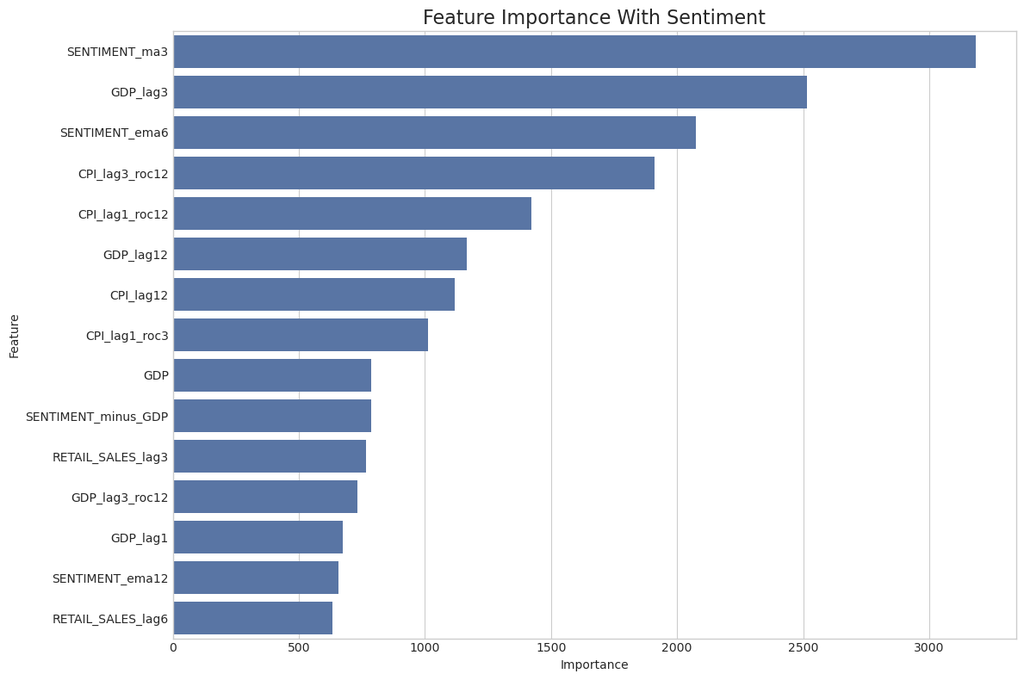

```
Saved figure to /home/mattgroho/github/economic-downturn-detector/docs/images/feature_importance_with_sentiment.png
```

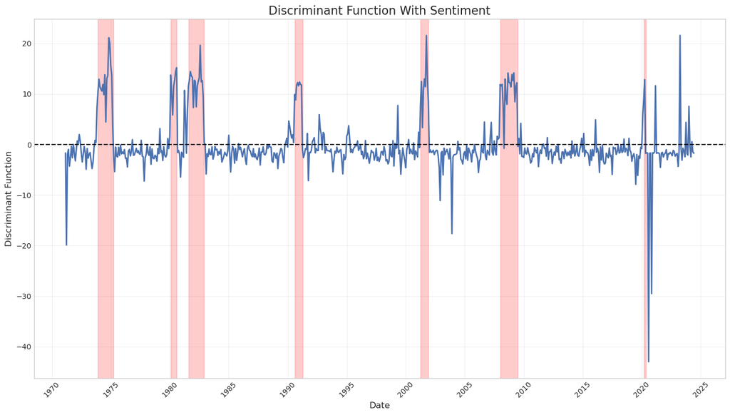

```
Saved figure to /home/mattgroho/github/economic-downturn-detector/docs/images/discriminant_time_series_with_sentiment.png

MDA Model WITHOUT Sentiment Features:
Removed 271 sentiment-related features
2025-06-12 13:49:37,121 - econ_downturn.features.normalization - INFO - Normalized data using standard method, shape: (640, 201)
2025-06-12 13:49:37,123 - econ_downturn.models.mda - INFO - Training set shape: (448, 200), Testing set shape: (192, 200)
2025-06-12 13:49:37,137 - econ_downturn.models.mda - INFO - Accuracy: 0.9375
2025-06-12 13:49:37,138 - econ_downturn.models.mda - INFO - Confusion Matrix:
[[159  11]
 [  1  21]]
2025-06-12 13:49:37,139 - econ_downturn.models.mda - INFO - Classification Report:
              precision    recall  f1-score   support

         0.0       0.99      0.94      0.96       170
         1.0       0.66      0.95      0.78        22

    accuracy                           0.94       192
   macro avg       0.82      0.94      0.87       192
weighted avg       0.96      0.94      0.94       192

2025-06-12 13:49:37,209 - econ_downturn.models.mda - INFO - Cross-Validation Scores: [0.96875   0.9375    0.9140625 0.953125  0.9375   ]
2025-06-12 13:49:37,211 - econ_downturn.models.mda - INFO - Mean CV Score: 0.9422
2025-06-12 13:49:37,213 - econ_downturn.models.mda - INFO - Top 5 Most Important Features:
            Feature  Importance
109  CPI_lag3_roc12  964.867841
11         GDP_lag3  799.923460
0               GDP  647.022671
20         CPI_lag6  604.350083
106  CPI_lag1_roc12  594.980503
Accuracy: 0.9375

Confusion Matrix:
[[159  11]
 [  1  21]]

Classification Report:
              precision    recall  f1-score   support

         0.0       0.99      0.94      0.96       170
         1.0       0.66      0.95      0.78        22

    accuracy                           0.94       192
   macro avg       0.82      0.94      0.87       192
weighted avg       0.96      0.94      0.94       192


Cross-Validation Scores: [0.96875   0.9375    0.9140625 0.953125  0.9375   ]
Mean CV Score: 0.9422
```

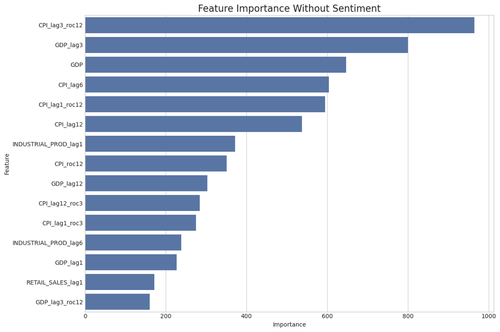

```
Saved figure to /home/mattgroho/github/economic-downturn-detector/docs/images/feature_importance_without_sentiment.png
```

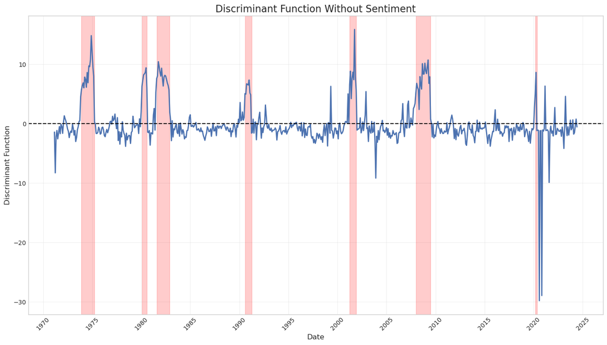

```
Saved figure to /home/mattgroho/github/economic-downturn-detector/docs/images/discriminant_time_series_without_sentiment.png
```

```python
def compare_mda_models(data, with_sentiment=True):
    """
    Compare MDA models with and without consumer sentiment features.

    Parameters
    ----------
    data : pandas.DataFrame
        Input dataset
    with_sentiment : bool
        Whether to include sentiment features

    Returns
    -------
    dict
        MDA results
    """
    # Make a copy of the data
    df = data.copy()

    # Identify sentiment-related columns
    sentiment_cols = [col for col in df.columns if 'SENTIMENT' in col]

    # Remove sentiment features if not including them
    if not with_sentiment:
        df = df.drop(columns=sentiment_cols)
        print(f"Removed {len(sentiment_cols)} sentiment-related features")

    # Normalize the data
    df_normalized, _ = normalize_data(df)

    # Separate features and target
    X = df_normalized.drop(columns=['recession'])
    y = df_normalized['recession']

    # Apply MDA
    mda_results = apply_mda(X, y)

    # Print model performance metrics
    print(f"Accuracy: {mda_results['accuracy']:.4f}")
    print("\nConfusion Matrix:")
    print(mda_results['conf_matrix'])
    print("\nClassification Report:")
    print(mda_results['class_report'])
    print(f"\nCross-Validation Scores: {mda_results['cv_scores']}")
    print(f"Mean CV Score: {mda_results['cv_scores'].mean():.4f}")

    # Plot feature importances
    if mda_results['feature_importance'] is not None:
        fig = plot_feature_importance(mda_results['feature_importance'])
        plt.title(f"Feature Importance {'With' if with_sentiment else 'Without'} Sentiment", fontsize=16)
        plt.show()
        save_figure(fig, f"feature_importance_{'with' if with_sentiment else 'without'}_sentiment.png")

    # Create and plot discriminant time series
    discriminant_df = create_discriminant_time_series(mda_results['model'], X, y)
    fig = plot_discriminant_time_series(discriminant_df)
    plt.title(f"Discriminant Function {'With' if with_sentiment else 'Without'} Sentiment", fontsize=16)
    plt.show()
    save_figure(fig, f"discriminant_time_series_{'with' if with_sentiment else 'without'}_sentiment.png")

    return mda_results

# Compare MDA models with and without sentiment features
print("\nMDA Model WITH Sentiment Features:")
mda_with_sentiment = compare_mda_models(data_with_transformations, with_sentiment=True)

print("\nMDA Model WITHOUT Sentiment Features:")
mda_without_sentiment = compare_mda_models(data_with_transformations, with_sentiment=False)
```

## Testing Our Selected Features

Now let's see if our feature selection actually worked. Do the hand-picked features perform better than using everything we've got?

```
MDA Model with ANOVA-Selected Features:
2025-06-12 13:49:37,610 - econ_downturn.features.normalization - INFO - Normalized data using standard method, shape: (640, 21)
2025-06-12 13:49:37,618 - econ_downturn.models.mda - INFO - Training set shape: (448, 20), Testing set shape: (192, 20)
2025-06-12 13:49:37,626 - econ_downturn.models.mda - INFO - Accuracy: 0.9323
2025-06-12 13:49:37,627 - econ_downturn.models.mda - INFO - Confusion Matrix:
[[161   9]
 [  4  18]]
2025-06-12 13:49:37,627 - econ_downturn.models.mda - INFO - Classification Report:
              precision    recall  f1-score   support

         0.0       0.98      0.95      0.96       170
         1.0       0.67      0.82      0.73        22

    accuracy                           0.93       192
   macro avg       0.82      0.88      0.85       192
weighted avg       0.94      0.93      0.94       192

2025-06-12 13:49:37,639 - econ_downturn.models.mda - INFO - Cross-Validation Scores: [0.921875  0.9375    0.9296875 0.9296875 0.9296875]
2025-06-12 13:49:37,640 - econ_downturn.models.mda - INFO - Mean CV Score: 0.9297
2025-06-12 13:49:37,642 - econ_downturn.models.mda - INFO - Top 5 Most Important Features:
               Feature   Importance
14      SENTIMENT_sqrt  1348.680805
13       SENTIMENT_log   541.935223
17    SENTIMENT_minmax   243.520210
0   CONSUMER_SENTIMENT   243.520210
16    SENTIMENT_zscore   243.520210
Accuracy: 0.9323

Confusion Matrix:
[[161   9]
 [  4  18]]

Classification Report:
              precision    recall  f1-score   support

         0.0       0.98      0.95      0.96       170
         1.0       0.67      0.82      0.73        22

    accuracy                           0.93       192
   macro avg       0.82      0.88      0.85       192
weighted avg       0.94      0.93      0.94       192


Cross-Validation Scores: [0.921875  0.9375    0.9296875 0.9296875 0.9296875]
Mean CV Score: 0.9297
```

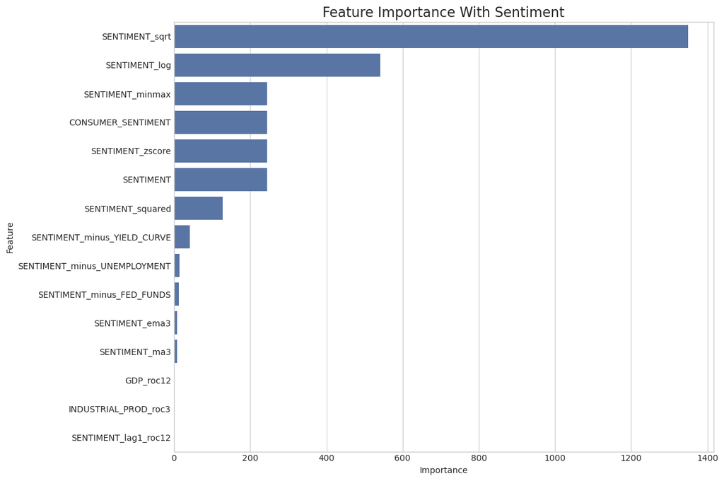

```
Saved figure to /home/mattgroho/github/economic-downturn-detector/docs/images/feature_importance_with_sentiment.png
```

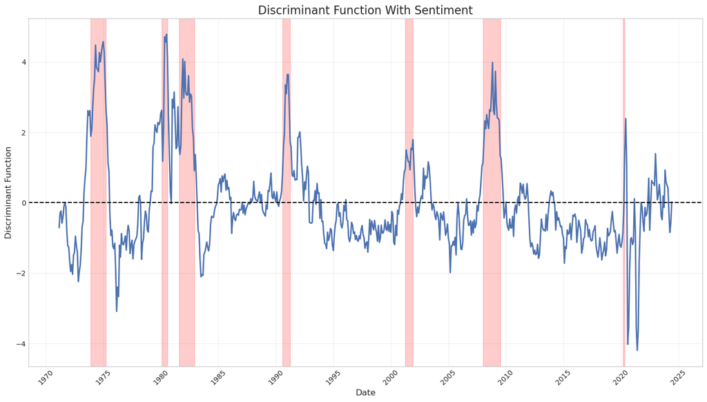

```
Saved figure to /home/mattgroho/github/economic-downturn-detector/docs/images/discriminant_time_series_with_sentiment.png

MDA Model with RFE-Selected Features:
2025-06-12 13:49:38,077 - econ_downturn.features.normalization - INFO - Normalized data using standard method, shape: (640, 21)
2025-06-12 13:49:38,079 - econ_downturn.models.mda - INFO - Training set shape: (448, 20), Testing set shape: (192, 20)
2025-06-12 13:49:38,085 - econ_downturn.models.mda - INFO - Accuracy: 0.9427
2025-06-12 13:49:38,085 - econ_downturn.models.mda - INFO - Confusion Matrix:
[[165   5]
 [  6  16]]
2025-06-12 13:49:38,088 - econ_downturn.models.mda - INFO - Classification Report:
              precision    recall  f1-score   support

         0.0       0.96      0.97      0.97       170
         1.0       0.76      0.73      0.74        22

    accuracy                           0.94       192
   macro avg       0.86      0.85      0.86       192
weighted avg       0.94      0.94      0.94       192

2025-06-12 13:49:38,102 - econ_downturn.models.mda - INFO - Cross-Validation Scores: [0.96875   0.984375  0.9453125 0.9375    0.953125 ]
2025-06-12 13:49:38,103 - econ_downturn.models.mda - INFO - Mean CV Score: 0.9578
2025-06-12 13:49:38,105 - econ_downturn.models.mda - INFO - Top 5 Most Important Features:
                     Feature  Importance
1             FED_FUNDS_lag3    2.520513
5                   GDP_roc3    1.846467
7   CONSUMER_SENTIMENT_roc12    1.844936
13  INITIAL_CLAIMS_lag1_roc3    1.563386
6        HOUSING_STARTS_roc3    1.307836
Accuracy: 0.9427

Confusion Matrix:
[[165   5]
 [  6  16]]

Classification Report:
              precision    recall  f1-score   support

         0.0       0.96      0.97      0.97       170
         1.0       0.76      0.73      0.74        22

    accuracy                           0.94       192
   macro avg       0.86      0.85      0.86       192
weighted avg       0.94      0.94      0.94       192


Cross-Validation Scores: [0.96875   0.984375  0.9453125 0.9375    0.953125 ]
Mean CV Score: 0.9578
```

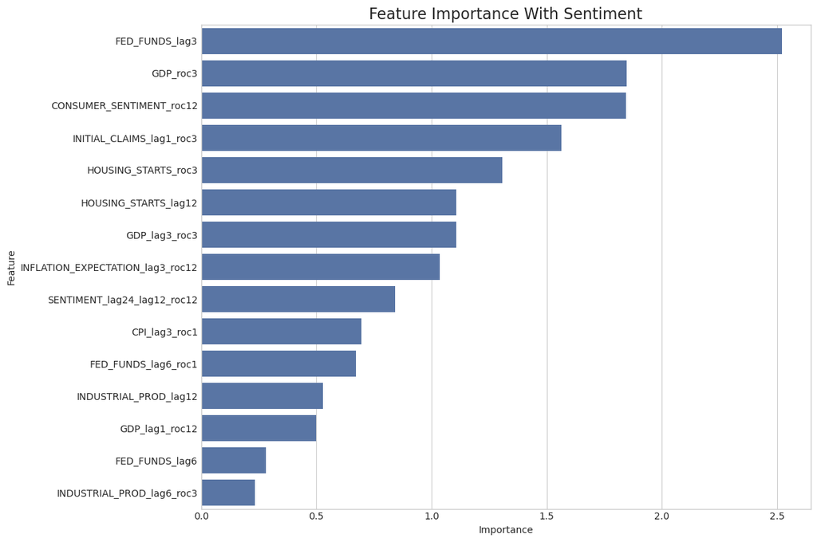

```
Saved figure to /home/mattgroho/github/economic-downturn-detector/docs/images/feature_importance_with_sentiment.png
```

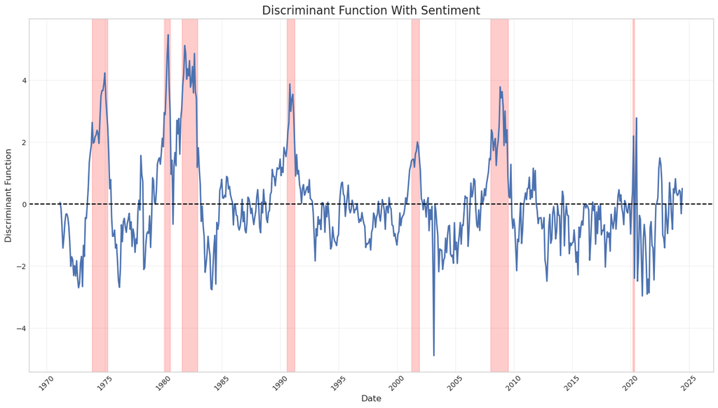

```
Saved figure to /home/mattgroho/github/economic-downturn-detector/docs/images/discriminant_time_series_with_sentiment.png
```

```python
# Add recession indicator to selected features
X_selected_anova_with_target = X_selected_anova.copy()
X_selected_anova_with_target['recession'] = y

X_selected_rfe_with_target = X_selected_rfe.copy()
X_selected_rfe_with_target['recession'] = y

# Apply MDA to ANOVA-selected features
print("\nMDA Model with ANOVA-Selected Features:")
mda_anova = compare_mda_models(X_selected_anova_with_target, with_sentiment=True)

# Apply MDA to RFE-selected features
print("\nMDA Model with RFE-Selected Features:")
mda_rfe = compare_mda_models(X_selected_rfe_with_target, with_sentiment=True)
```